# Machine Learning Project

#### Explainability of Xgboost

Just as with random forest, we rank the importance of the variables in the model.

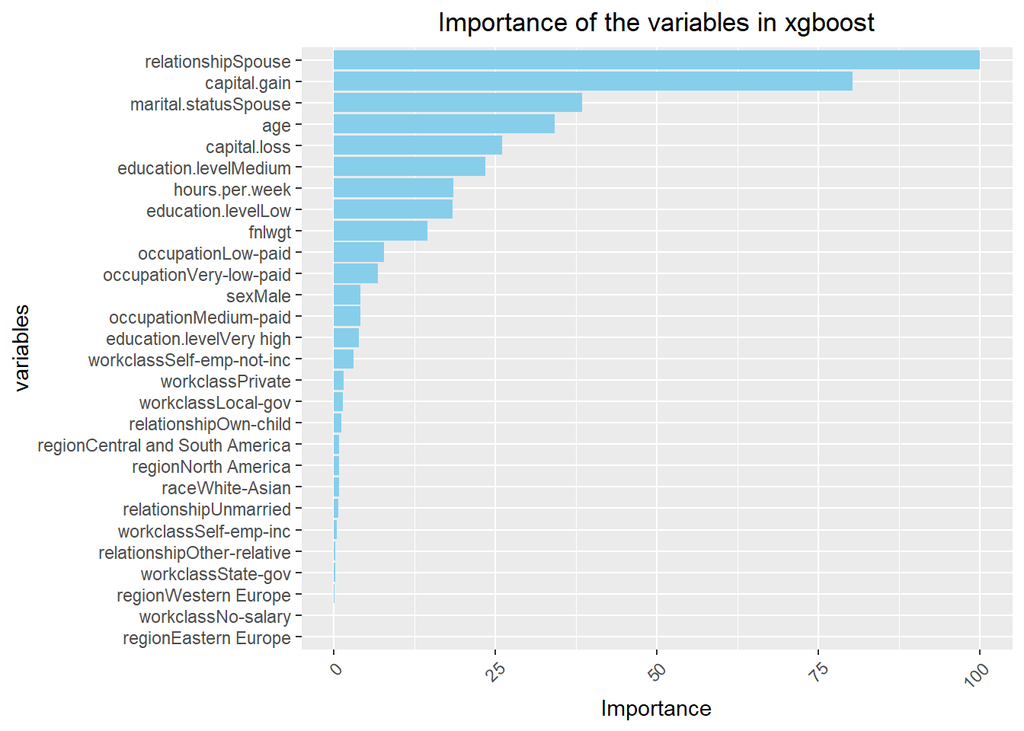

```r
#Extract the importance of the variables from the random forest
#model
importance_df <- as.data.frame(varImp(xgb_model)$importance)

# Plot using ggplot2
ggplot(importance_df, aes(x = reorder(rownames(importance_df), Overall), y = Overall)) +
  geom_bar(stat = "identity", fill = "skyblue") +
  labs(x = "variables", y = "Importance", title = "Importance of the variables in xgboost") +
  theme(axis.text.x = element_text(angle = 45, hjust = 1)) +
  coord_flip() +
  theme(plot.title = element_text(hjust = 0.5))
```

The $5$ most “important” variables in xgboost are similar to the ones in random forest, but now, “knlwgt” is not among them and the fith most important one is “capital.loss”. Besides, the “feature” with more importance is “relationshipSpouse”. As above, we show partial dependent plots of these variables:

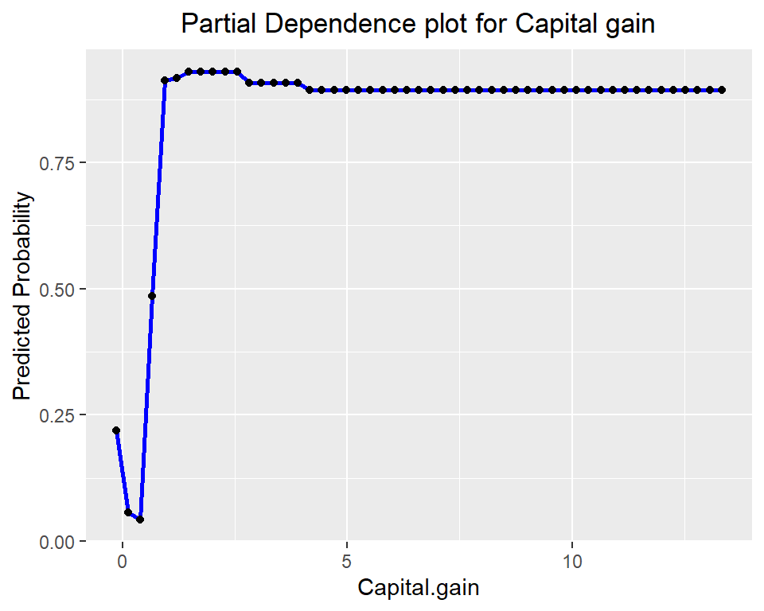

```r
pdp <- partial(xgb_model, pred.var = "capital.gain", which.class = 2, plot = FALSE, prob = TRUE, rug = TRUE)

#Convert the results into a dataframe
pdp_df <- data.frame(x = pdp$capital.gain, y = pdp$yhat)

#plot the results
ggplot(pdp_df, aes(x = x, y = y)) +
  geom_line(color = "blue", size = 1) +
  geom_point(color = "black") + #In black we represent the real points
  labs(x = "Capital.gain", y = "Predicted Probability",
       title = "Partial Dependence plot for Capital gain") +
       theme(plot.title = element_text(hjust = 0.5))
```

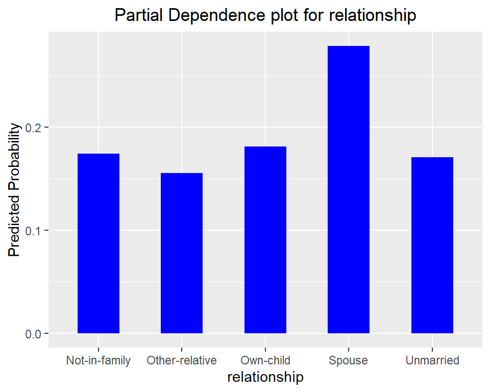

```r
pdp <- partial(xgb_model, pred.var = "relationship", which.class = 2, plot = FALSE, prob = TRUE, rug = TRUE)

#Convert the results into a dataframe
pdp_df <- data.frame(x = pdp$relationship, y = pdp$yhat)

#plot the results
ggplot(pdp_df, aes(x = x, y = y)) +
  geom_bar(stat = "identity", fill = "blue", width = 0.5) +
  labs(x = "relationship", y = "Predicted Probability",
       title = "Partial Dependence plot for relationship") +
  theme(plot.title = element_text(hjust = 0.5))
```

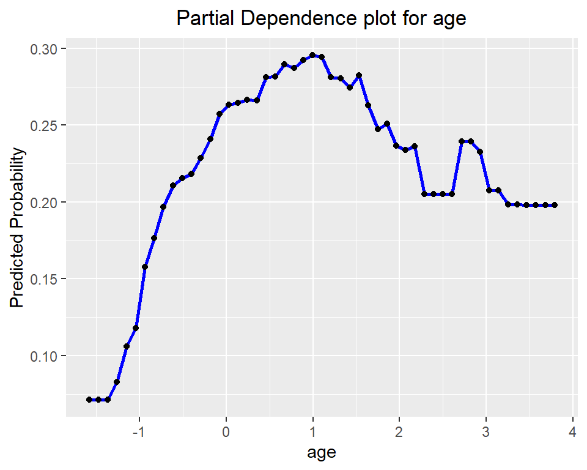

```r
pdp <- partial(xgb_model, pred.var = "age", which.class = 2, plot = FALSE, prob = TRUE, rug = TRUE)

#Convert the results into a dataframe
pdp_df <- data.frame(x = pdp$age, y = pdp$yhat)

#plot the results
ggplot(pdp_df, aes(x = x, y = y)) +
  geom_line(color = "blue", size = 1) +
  geom_point(color = "black") + #In black we represent the real points
  labs(x = "age", y = "Predicted Probability",
       title = "Partial Dependence plot for age") +
       theme(plot.title = element_text(hjust = 0.5))
```

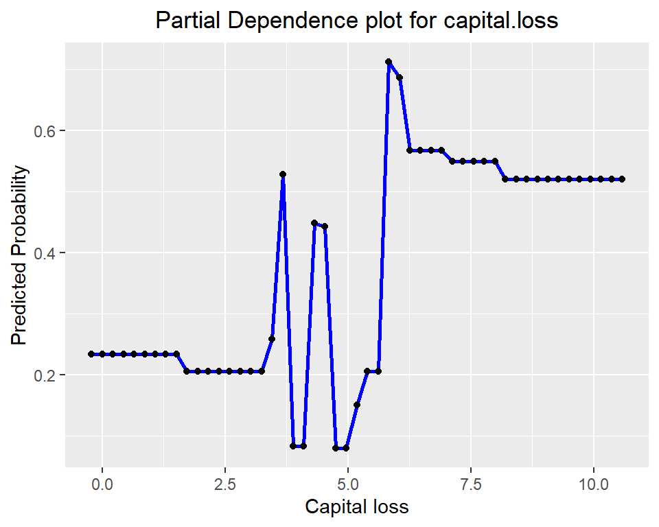

```r
pdp <- partial(xgb_model, pred.var = "capital.loss", which.class = 2, plot = FALSE, prob = TRUE, rug = TRUE)

#Convert the results into a dataframe
pdp_df <- data.frame(x = pdp$capital.loss, y = pdp$yhat)

#plot the results
ggplot(pdp_df, aes(x = x, y = y)) +
  geom_line(color = "blue", size = 1) +
  geom_point(color = "black") + #In black we represent the real points
  labs(x = "Capital loss", y = "Predicted Probability",
       title = "Partial Dependence plot for capital.loss") +
       theme(plot.title = element_text(hjust = 0.5))
```

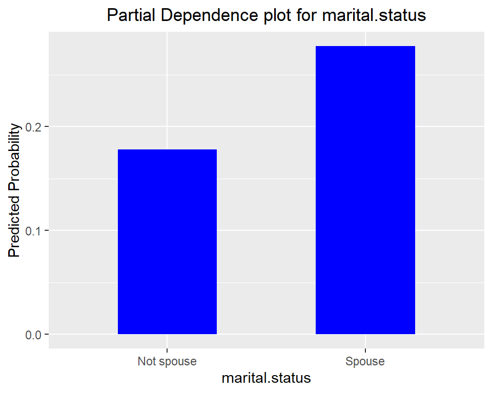

```r
pdp <- partial(xgb_model, pred.var = "marital.status", which.class = 2, plot = FALSE, prob = TRUE, rug = TRUE)

#Convert the results into a dataframe
pdp_df <- data.frame(x = pdp$marital.status, y = pdp$yhat)

# plot the results as a barplot
ggplot(pdp_df, aes(x = x, y = y)) +
  geom_bar(stat = "identity", fill = "blue", width = 0.5) +
  labs(x = "marital.status", y = "Predicted Probability",
       title = "Partial Dependence plot for marital.status") +
  theme(plot.title = element_text(hjust = 0.5))
```

The partial plots are very similar to the ones in random forest. The only new one is the partial plot of the capital loss. For small capital losses, the probability of being classified as positive by the model is low. Then, as it increases, it starts oscillating, and finally, for high values, it seems to stabilize around $p=0.5$. This makes sense since if an individual can afford to invest a lot of money and lose it, it is likely that he or she earns more than $50,000 a year.

#### Neural Networks

Neural networks are a class of machine learning algorithms that consist of interconnected nodes, or neurons, organized in layers. Each neuron applies a nonlinear transformation to its inputs and passes the result to neurons in the next layer. Through a process called backpropagation, neural networks adjust the weights of connections between neurons to minimize a defined loss function, enabling them to learn complex patterns and relationships in data. They’re characterized by their ability to approximate arbitrary functions and are widely used in various domains for tasks such as regression, classification, and reinforcement learning. For this particular case, we will train a Neural Network with one single hidden layer:

```r
ctrl <- trainControl(method = "cv",
                     number = 5, classProbs = TRUE)

#neural network with one hidden layer
nn_model <- train(income ~.,
                  method = "nnet",
                  data = train,
                  MaxNWts = 1000,
                  maxit = 100,
                  tuneGrid = expand.grid(size=c(2,4,6), decay=c(0.01,0.001)),
                  metric = "Accuracy",
                  trControl = ctrl,
                  trace = FALSE)

predictions_nn <- predict(nn_model,newdata = test_imputed)
conf_matrix <- confusionMatrix(data = predictions_nn, reference = test_imputed$income)
```

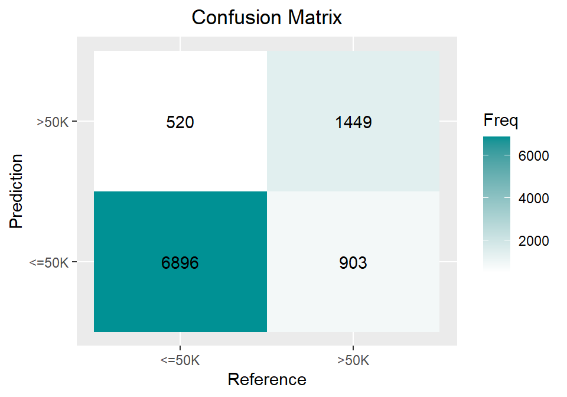

```r
#plot the confusion matrix and several quantities
conf_matrix_table <- as.data.frame(conf_matrix$table)


ggplot(conf_matrix_table, aes(x = Reference, y = Prediction,fill= Freq)) +
        geom_tile() + geom_text(aes(label=Freq)) +
        scale_fill_gradient(low="white", high="#009194") +
        labs(x = "Reference",y = "Prediction") +
        scale_x_discrete(labels=c("<=50K",">50K")) +
        scale_y_discrete(labels=c("<=50K", ">50K")) +
        ggtitle("Confusion Matrix") +
        theme(plot.title = element_text(hjust = 0.5))
```

```r
#dataframe with some metrics
metrics_df <- data.frame(
  Value = c(conf_matrix$byClass["Sensitivity"],
            conf_matrix$byClass["Specificity"],
            conf_matrix$overall["Kappa"],
            conf_matrix$overall["Accuracy"])
)

#optimal hyperparameters of the neural network with one hidden layer
nn_model$bestTune
```

```
##   size decay
## 6    6  0.01
```

```r
#Show the metrics
print(metrics_df)
```

```
##                 Value
## Sensitivity 0.9298813
## Specificity 0.6160714
## Kappa       0.5780933
## Accuracy    0.8543202
```

The accuracy and the rest of metrics are slightly better than in the logistic regression model but worse than the ones predicted by random forest and xgboost.

```r
ctrl <- trainControl(method = "cv",
                     number = 5, classProbs = TRUE)

dnn_model <- train(income ~.,
                  method = "dnn",
                  data = train,
                  numepochs = 20,
                  tuneGrid = expand.grid(layer1 = 1:10,
                                         layer2 = 0:5,
                                         layer3 = 0:5,
                                         hidden_dropout = 0,
                                         visible_dropout = 0),
                  metric = "Accuracy",
                  trControl = ctrl)

predictions_dnn <- predict(dnn_model,newdata = test_imputed)
conf_matrix <- confusionMatrix(data = predictions_dnn, reference = test_imputed$income)
```

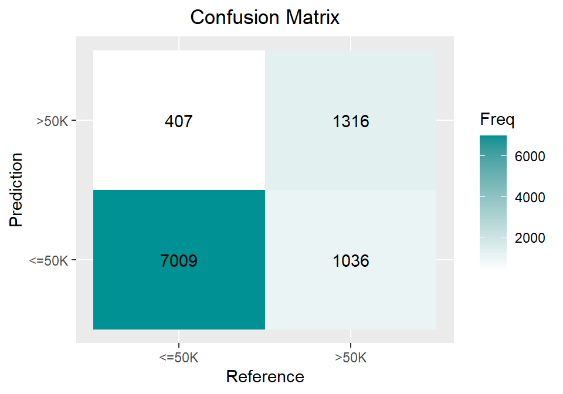

```r
#plot the confusion matrix and several quantities
conf_matrix_table <- as.data.frame(conf_matrix$table)


ggplot(conf_matrix_table, aes(x = Reference, y = Prediction,fill= Freq)) +
        geom_tile() + geom_text(aes(label=Freq)) +
        scale_fill_gradient(low="white", high="#009194") +
        labs(x = "Reference",y = "Prediction") +
        scale_x_discrete(labels=c("<=50K",">50K")) +
        scale_y_discrete(labels=c("<=50K", ">50K")) +
        ggtitle("Confusion Matrix") +
        theme(plot.title = element_text(hjust = 0.5))
```

```r
#dataframe with some metrics
metrics_df <- data.frame(
  Value = c(conf_matrix$byClass["Sensitivity"],
            conf_matrix$byClass["Specificity"],
            conf_matrix$overall["Kappa"],
            conf_matrix$overall["Accuracy"])
)

#optimal hyperparameters of the deep neural network
dnn_model$bestTune
```

```
##     layer1 layer2 layer3 hidden_dropout visible_dropout
## 271      8      3      0              0               0
```

```r
#Show the metrics
print(metrics_df)
```

```
##                 Value
## Sensitivity 0.9451187
## Specificity 0.5595238
## Kappa       0.5553502
## Accuracy    0.8522727
```

The accuracy obtained is very similar to the accuracy of the neural network with just one single hidden layer, but slightly smaller. This may be because the neural network with just one hidden layer might generalize better due to its simplicity, while the DNN may overfit the training data and it may require a more exhaustive hyperparameter grid search.

#### Ensemble learning

Finally in order to improve the accuracy, we train an ensemble model. Ensemble is an ML technique that combines the predictions of multiple ML individual models. The idea behind ensemble methods is that by aggregating the predictions of multiple models, the weaknesses of individual models can be compensated for, resulting in improved overall performance. This is the case of some ML algorithms such as random forest or xgboost, which are ensembles of decision trees. In this case, the ensemble is formed by the $5$ ML algorithms with the highest accuracy: xgb, rf, nn, svm, dnn. The predicted class will be obtained as the mode of the predicted classes by each ML algorithm (majority vote).

```r
#Create a function that computes the mode of a vector
mode <- function(v) {
  uniqv <- unique(v)
  uniqv[which.max(tabulate(match(v, uniqv)))]
}

#Predictions of the ensemble learning method as the majority vote from the selected ML algorithms
ensemble_predictions = apply(data.frame(predictions_xgb,predictions_nn, predictions_svm_hpo, predictions_dnn, predictions_rf_hpo), 1, mode)

#The variable ensemble predictions is codified as a character so we codify it as a factor
ensemble_predictions <- factor(ensemble_predictions, levels = levels(test_imputed$income))
conf_matrix <- confusionMatrix(data = ensemble_predictions, reference = test_imputed$income)
```

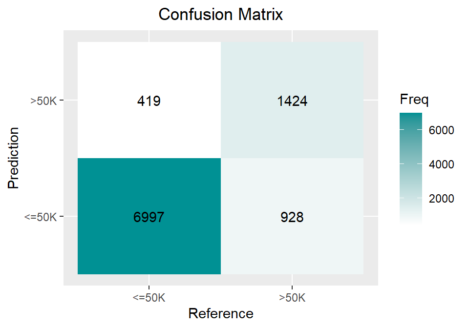

```r
#plot the confusion matrix and several quantities
conf_matrix_table <- as.data.frame(conf_matrix$table)

ggplot(conf_matrix_table, aes(x = Reference, y = Prediction,fill= Freq)) +
        geom_tile() + geom_text(aes(label=Freq)) +
        scale_fill_gradient(low="white", high="#009194") +
        labs(x = "Reference",y = "Prediction") +
        scale_x_discrete(labels=c("<=50K",">50K")) +
        scale_y_discrete(labels=c("<=50K", ">50K")) +
        ggtitle("Confusion Matrix") +
        theme(plot.title = element_text(hjust = 0.5))
```

```r
#dataframe with some metrics
metrics_df <- data.frame(
  Value = c(conf_matrix$byClass["Sensitivity"],
            conf_matrix$byClass["Specificity"],
            conf_matrix$overall["Kappa"],
            conf_matrix$overall["Accuracy"])
)

#Show the metrics
print(metrics_df)
```

```
##                 Value
## Sensitivity 0.9435005
## Specificity 0.6054422
## Kappa       0.5927391
## Accuracy    0.8621007
```

The accuracy obtained is higher than the accuracy of some of the ML methods in the ensemble but still lower than rf and xgboost accuracy. The reason behind may be the lack of diversity of ML methods in the ensemble (only five) and the fact that the individual ML algorithm require a higher search grid for hyperparameter tunning

## ROC Curves

In the previous section, we focused on identifying the machine learning method with the highest accuracy, which can be beneficial in various applications such as economic research and statistical analysis. Now, we are comparing the ROC curves of different machine learning methods, excluding SVM, where ‘probabilities’ are not well defined. We are assessing the models based on the Area Under the Curve (AUC), which measures a model’s ability to distinguish between the classes of the target variable. This evaluation can be particularly useful in scenarios such as income prediction for tax estimates, where governments use income prediction models to estimate future earnings for taxpayers and formulate fiscal policies and budgets accordingly. In such cases, it is crucial to employ a model that accurately distinguishes between individuals earning more than $50,000 to allocate fiscal resources effectively, ensuring fair taxation for those with lower incomes while appropriately taxing higher earners.

```r
#compute the probabilities of being classified as positive obtained in the ML models (except SVM)
probs_knn <- predict(knn_model_hpo, newdata = test_imputed, type = "prob")[,2]
probs_tree <- predict(model_tree_hpo, newdata = test_imputed, type = "prob")[,2]
probs_rf <- predict(model_rf_hpo, newdata = test_imputed, type = "prob")[,2]
probs_xgb <- predict(xgb_model, newdata = test_imputed, type = "prob")[,2]
probs_nn <- predict(nn_model, newdata = test_imputed, type = "prob")[,2]
probs_dnn <- predict(dnn_model, newdata = test_imputed, type = "prob")[,2]
```

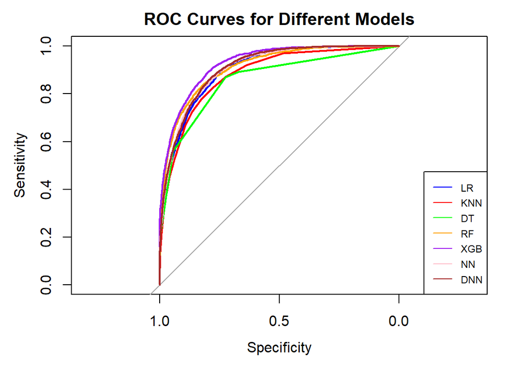

```r
#Compute the different ROC curves and plot them together
roc_lr <- roc(test_imputed$income ~ probabilities_logit)
roc_knn <- roc(test_imputed$income ~ probs_knn)
roc_tree <- roc(test_imputed$income ~ probs_tree)
roc_rf <- roc(test_imputed$income ~ probs_rf)
roc_xgb <- roc(test_imputed$income ~ probs_xgb)
roc_nn <- roc(test_imputed$income ~ probs_nn)
roc_dnn <- roc(test_imputed$income ~ probs_dnn)
plot(roc_lr, col = "blue", main = "ROC Curves for Different Models")
plot(roc_knn, add = TRUE, col = "red")
plot(roc_tree, add = TRUE, col = "green")
plot(roc_rf, add = TRUE, col = "orange")
plot(roc_xgb, add = TRUE, col = "purple")
plot(roc_nn, add = TRUE, col = "pink")
plot(roc_dnn, add = TRUE, col = "brown")

# Add legend
legend("bottomright",
       legend = c("LR", "KNN", "DT", "RF", "XGB", "NN", "DNN"),
       col = c("blue", "red", "green", "orange", "purple", "pink", "brown"),
       lty = 1,
       cex = 0.7)
```

From the graph, although it may be challenging to discern all the curves, it is evident that XGBoost has the highest AUC value, while Decision Trees have the lowest. The AUC values are:

```r
auc_values <- data.frame( Model = c('LR','KNN','DT','RF','XGB','NN','DNN'),
                          AUC = c(auc(roc_lr), auc(roc_knn), auc(roc_tree),
                                  auc(roc_rf), auc(roc_xgb), auc(roc_nn), auc(roc_dnn)))
auc_values
```

```
##   Model       AUC
## 1    LR 0.9029427
## 2   KNN 0.8827406
## 3    DT 0.8606579
## 4    RF 0.9109802
## 5   XGB 0.9280922
## 6    NN 0.9077404
## 7   DNN 0.9095579
```

The model with the highest Area Under the Curve (AUC) is XGBoost (xgb) with an AUC of 0.92, followed closely by Random Forest. This indicates that the model is highly effective in discriminating between the two classes. On the other hand, it is worth noting that Logistic Regression achieved an AUC of 0.90, which is superior to the AUC values of Decision Trees and KNN.

## Cost sensitive learning

```r
#Function that computes the cost and the profit for each element of the confusion matrix in function
#of the probability p
compute_profit <- function(p){

  #Profit of true negatives:0
  #Profit of false positives: - 10
  #Profit of true positives: p*1000
  #Profit of false negatives: - 10
  profit <- c(0,-20,0, 1000*p - 20)
  return(profit)

}
```

```r
#Set the seed for reproducible results
set.seed(666)
#vector containing the different probability thresholds
thresholds <- seq(0.05,0.95, length = 15)
#number of models that will be trained for each threshold
n_splits = 50
profit <- matrix(0, nrow = n_splits, ncol = length(thresholds))
#To accelerate the computing part, we randomly choose a sample of 1000 observations only
train_subsample <- train[sample(1:1000),]
#loop for all possible thresholds
for(j in 1:length(thresholds)){
  #We do 50 different splits of the training data for each threshold
  for(i in 1:n_splits){
    #A 80-20%
    d = createDataPartition(train_subsample$income, p = 0.8, list = FALSE)
    #We define our train_train and train_test samples
    train_train <- train_subsample[d,]
    train_test <- train_subsample[-d,]

    #We train the xgboost model using the hyperparameters obtained with hyperparameter tunning
    best_params <- xgb_model$bestTune

    #return the probabilities
    ctrl <- trainControl(method = "none", classProbs = TRUE)

    #train a model using xgboost with the hyperparameters calculated previously
    xgb_model2 <- train(income ~ .,
                         data = train_train,
                         method = "xgbTree",
                         trControl = ctrl,
                         tuneGrid = expand.grid(nrounds = best_params$nrounds,
                                                max_depth = best_params$max_depth,
                                                eta = best_params$eta,
                                                gamma = best_params$gamma,
                                                colsample_bytree = best_params$colsample_bytree,
                                                min_child_weight = best_params$min_child_weight,
                                                subsample = best_params$subsample)
    )

     #we compute the predicted probabilities
     threshold_probabilities <- predict(xgb_model2, newdata = train_test, type = 'prob')[,2]

     #Use the the threshold to classify the class of the output
    levels_threshold <- levels(train_test$income)
    threshold_classes <- ifelse(threshold_probabilities > thresholds[j], levels_threshold[2],       levels_threshold[1])
    threshold_classes <- factor(threshold_classes, levels = levels_threshold)
    #compute the table with the confusion matrix of the model
    CM = confusionMatrix(threshold_classes, train_test$income)$table
    #update the a_{ij} element of the profit matrix
    profit[i,j] <- sum(as.vector(CM)*compute_profit(0.1))
  }
}
```

For each probability threshold, we show a boxplot with the distribution of the company’s profit

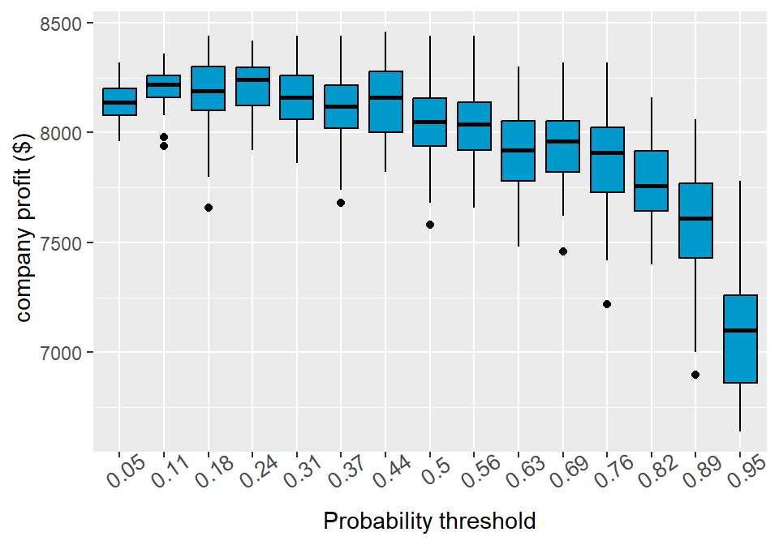

```r
#Boxplot with the results
ggplot(data = data.frame(reps=reshape2::melt(t(profit))$value,
                         cutoff = factor(rep(thresholds, n_splits), labels = round(thresholds, 2)))) +
  geom_boxplot(aes(x = cutoff, y = reps), fill = 'deepskyblue3', col = 'black') +
  labs(x = 'Probability threshold', y = ' company profit ($)') +
  theme(axis.text.x = element_text(angle = 35, size = 10), plot.title = element_text(hjust = 0.5))
```

The optimal threshold corresponds to the value of the probability threshold that lead to the highest median in the profit distribution. In this case, $p_{op}=0.24$, which is lower than the default probability threshold $p=0.5$. The reason is that in order to optimize the profit, the company must send advertisement to the most of its potential customers. Nevertheless, the probability threshold cannot be arbitrarily low because if not, they well spend to much sending advertise to individuals who cannot afford their product or they are not interested in it.

Confusion matrix obtained using the optimal threshold to to classify the classes using the predictions of the xgb model trained with the whole training dataset:

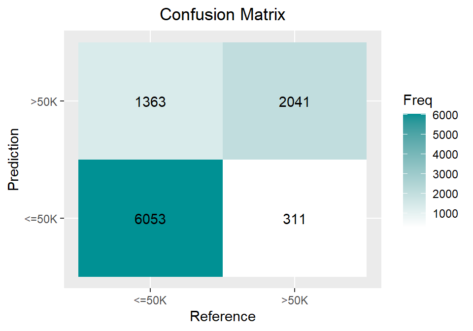

```r
probs_xgb <- predict(xgb_model, newdata = test_imputed, type = "prob")[,2]
levels_test <- levels(test_imputed$income)
optimal_classes <- ifelse(probs_xgb > 0.24, levels_test[2],levels_test[1])
optimal_classes <- factor(optimal_classes, levels = levels_test)
conf_matrix <- confusionMatrix(data = optimal_classes, reference = test_imputed$income)
#plot the confusion matrix and several quantities
conf_matrix_table <- as.data.frame(conf_matrix$table)

ggplot(conf_matrix_table, aes(x = Reference, y = Prediction,fill= Freq)) +
        geom_tile() + geom_text(aes(label=Freq)) +
        scale_fill_gradient(low="white", high="#009194") +
        labs(x = "Reference",y = "Prediction") +
        scale_x_discrete(labels=c("<=50K",">50K")) +
        scale_y_discrete(labels=c("<=50K", ">50K")) +
        ggtitle("Confusion Matrix") +
        theme(plot.title = element_text(hjust = 0.5))
```

```r
#dataframe with some metrics
metrics_df <- data.frame(
  Value = c(conf_matrix$byClass["Sensitivity"],
            conf_matrix$byClass["Specificity"],
            conf_matrix$overall["Kappa"],
            conf_matrix$overall["Accuracy"])
)

#Show the metrics
print(metrics_df)
```

```
##                 Value
## Sensitivity 0.8162082
## Specificity 0.8677721
## Kappa       0.5933663
## Accuracy    0.8286241
```

The specificity, which represents the proportion of true positives, is 15% higher than the specificity obtained using p = 0.5, and the sensitivity is 15% lower. Therefore, using a lower threshold allows us to identify more individuals belonging to the positive class, with the drawback that it misclassifies some individuals who do not.

## Conclusions

Finally, a hypothetical scenario was presented in which a company wanted to sell a luxury product and, for that purpose, wished to send advertisements to potential customers. Therefore, they needed to correctly identify people who earn more than $50k per year. By iterating over probability thresholds, it was found that the company would achieve maximum profit using a probability threshold of 0.24 to classify the classes, achieving higher specificity than for p=0.5, but with lower sensitivity and accuracy.